# Geomapping tweets

Miguel Curiel

## Import existing Twitter data

To experiment with the idea of geomapping tweets, we will use an existing tweet dataset collected on Nov. 27, 2022. The dataset contains 9,570 #WorldCup2022 tweets. The source file is **#WorldCup2022_tweets.rda**

Afer you run the code below, you will see an R object called tweets. Click to see the tweets.

```r
load(file="#WorldCup2022_tweets.rda")
```

## Extract geographic information from the tweet data

The *lat_lng()* function can parse Twitter data with latitude and longitude. In the code below, it creates a new data frame called *geocodes* which contains only geo-tagged tweets.

```r
library(rtweet)
geocodes <- lat_lng(tweets)
geocodes <- geocodes[!is.na(geocodes$lat),] #remove non-geo-tagged tweets
```

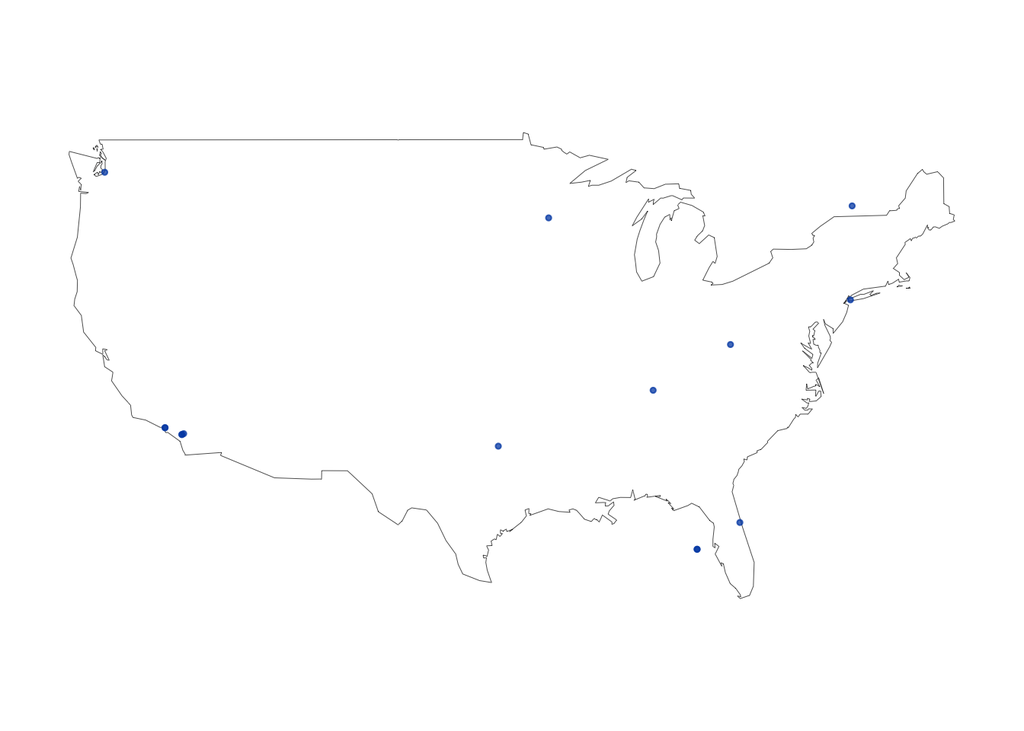

```r
library(ggplot2)
par(mar = c(0, 0, 0, 0))
maps::map("usa", lwd = .35)
with(geocodes, points(lng, lat, pch = 20, cex = .75, col = rgb(0, .3, .7, .75)))
```

## Visualize tweets using leaflet

You can use *leaflet* to create an interactive map showing the geo-tagged tweets. See how the two columns *lng* and *lat* are entered into the code below.

```r
library(leaflet)

map1 <- leaflet(data = geocodes) %>%
  addTiles() %>%
  setView(lng = -98.35, lat = 39.50, zoom = 3) %>%
  addCircleMarkers(lng = ~lng, lat = ~lat) %>%
  addProviderTiles("OpenStreetMap.Mapnik") %>%
  addCircleMarkers(
    stroke = FALSE, fillOpacity = 0.5
  )
```

```
## Assuming "lng" and "lat" are longitude and latitude, respectively
```

```r
map1
```

[interactive chart not shown]

## Leaflet with styles

You can change basemap templates and add features to the map. In the code below we will add text box to each geotag so that the tweet text appears when you click a geotag. See how the *text* column is used in the code.

```r
map2 <- leaflet(data = geocodes) %>%
  addTiles() %>%
  setView(lng = -98.35, lat = 39.50, zoom = 3) %>%
  addMarkers(lng = ~lng, lat = ~lat,popup = ~ as.character(text)) %>%
  addProviderTiles(providers$Esri.NatGeoWorldMap) %>% #select basemap template
  addCircleMarkers(
    stroke = FALSE, fillOpacity = 0.5
  )
```

```
## Assuming "lng" and "lat" are longitude and latitude, respectively
```

```r
map2
```

[interactive chart not shown]

## Create your own map!

Learn from the example and revise the code to create your own map. Please collect your own set of tweets and visualize geo-tagged tweets below.

```r
##set up Twitter search
# mytoken <- create_token(
#   app = "R_Workshop_DB",
#   consumer_key = "4EL1tCE2DG4OdtLrynOGnWsHi",
#   consumer_secret = "57Urg78Zkpoqj4M6ZPL8TOXp7X4o0IM4Thh2FzmUGrm0TmgviD",
#   access_token = "17917334-QzAR7yu42izruhOLsQEzVbHOVwXYHj0BrhMkqhJne",
#   access_secret = "fvNA7z3Sb1nVfmqCIEJvDxkIWyvGlkbe6xXgscnXFlvzj")

#download tweets
hashtag <- search_tweets("#indonesia", n = 10000, include_rts = FALSE)
```

```r
#convert to lat/long data
geocodes2 <- lat_lng(hashtag)
geocodes2 <- geocodes2[!is.na(geocodes2$lat),] #remove non-geo-tagged tweets
```

```r
#generate map

map3 <- leaflet(data = geocodes2) %>%
  addTiles() %>%
  setView(lng = -98.35, lat = 39.50, zoom = 3) %>%
  addCircleMarkers(lng = ~lng, lat = ~lat) %>%
  addProviderTiles("OpenStreetMap.Mapnik") %>%
  addCircleMarkers(
    stroke = FALSE, fillOpacity = 0.5
  ) %>%
  addLegend(title="#indonesia in Twitter after Mount Semeru's eruption", colors= c("blue"), labels=c("Tweets"))
```

```
## Assuming "lng" and "lat" are longitude and latitude, respectively
```

```r
map3
```

[interactive chart not shown]